# Storm Data Analysis - Types of Event

```
1. Across the United States, which types of events (as indicated in the EVTYPE variable) are most harmful with respect to population health?

2. Across the United States, which types of events have the greatest economic consequences?
```

The basic goal of this document is to explore the NOAA Storm Database and understand some basic concepts about weather events.

## Data Processing

Set the working directory:

```r
my.path <- "D:/Online Courses/Coursera/Data Science/5. Reproducible Research/Lab/Lab 2";
setwd(my.path);
```

Downloading data from the website: [Storm Data](https://d396qusza40orc.cloudfront.net/repdata%2Fdata%2FStormData.csv.bz2)

or you can download file using the file URL

```r
fileUrl <- "https://d396qusza40orc.cloudfront.net/repdata%2Fdata%2FStormData.csv.bz2";
fileZip <- "./repdata-data-StormData.csv.bs2";
if (file.exists(fileZip) == F) {
    download.file(fileUrl, fileZip, mode = "wb")
}
```

Reading data from the raw file:

```r
data <- read.csv("repdata-data-StormData.csv.bz2", header = TRUE, sep=",")
```

## Question 1: Across the United States, which types of events (as indicated in the EVTYPE variable) are most harmful with respect to population health?

Find the most harmful with respect to population health by FALITIES and INJURIES variable

```r
harm <- data$FATALITIES + data$INJURIES
maxharm <- max(harm)
maxharm
```

```
## [1] 1742
```

Subsetting data to find the most harmful with respect to population health

```r
mostharm <- data$EVTYPE[which(data$INJURIES + data$FATALITIES == maxharm)]
mostharm
```

```
## [1] TORNADO
## 985 Levels:    HIGH SURF ADVISORY  COASTAL FLOOD ... WND
```

## Question 2: Across the United States, which types of events have the greatest economic consequences?

Property Damage estimate in Billion dollar

```r
prop <- data$PROPDMG[which(data$PROPDMGEXP == "B")]
prop
```

```
##  [1]   5.00   0.10   2.10   1.60   1.00   5.00   2.50   1.20   3.00   1.70
## [11]   3.00   1.50   5.15   1.00   1.04   2.50   5.42   1.30   4.83   4.00
## [21]   1.00   1.50  10.00  16.93  31.30   4.00   7.35  11.26   5.88   2.09
## [31] 115.00   1.00   4.00   1.50   1.80   1.00   1.50   2.80   1.00   2.00
```

The maximum property damage:

```r
a <- max(prop)
a
```

```
## [1] 115
```

Crop Damage estimate in Billion dollar

```r
crop <- data$CROPDMG[which(data$CROPDMGEXP == "B")]
crop
```

```
## [1] 0.40 5.00 0.50 0.20 5.00 1.51 1.00 0.00 0.00
```

```r
b <- max(crop)
b
```

```
## [1] 5
```

We can clearly see that the property damage is 115 billion dollar, which is the the largest amount.

The type of event which creates the greatest economic consequences:

```r
econ <- data$EVTYPE[which((data$PROPDMG == a) & (data$PROPDMGEXP == "B"))]
econ
```

```
## [1] FLOOD
## 985 Levels:    HIGH SURF ADVISORY  COASTAL FLOOD ... WND
```

## Plotting

Number of injuries and fatalities caused by Storm

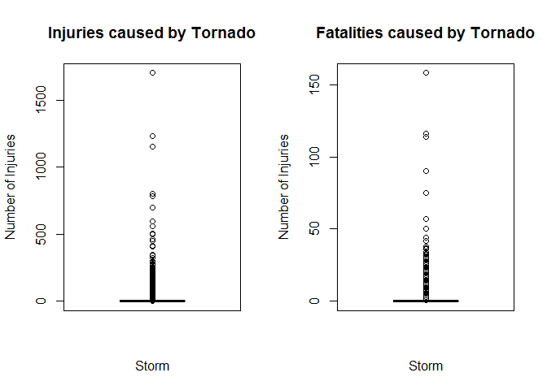

```r
tornado <- data[which(data$EVTYPE == "TORNADO"),]
par(mfrow=c(1,2))
boxplot(tornado$INJURIES, main ="Injuries caused by Tornado"
        ,xlab="Storm", ylab="Number of Injuries")
boxplot(tornado$FATALITIES, main ="Fatalities caused by Tornado"
        ,xlab="Storm", ylab="Number of Injuries")
```

The Property Damage caused by Flood

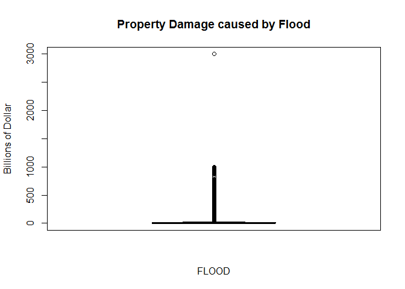

```r
boxplot(data$PROPDMG[data$EVTYPE=="FLOOD"]
        , main ="Property Damage caused by Flood"
        ,xlab="FLOOD", ylab="Billions of Dollar")
```

## Results

Question 1: Across the United States, which types of events (as indicated in the EVTYPE variable) are most harmful with respect to population health?

```r
mostharm <- data$EVTYPE[which(data$INJURIES + data$FATALITIES == maxharm)]
mostharm
```

```
## [1] TORNADO
## 985 Levels:    HIGH SURF ADVISORY  COASTAL FLOOD ... WND
```

The answer is TORNADO.

Question 2: Across the United States, which types of events have the greatest economic consequences?

```r
econ <- data$EVTYPE[which((data$PROPDMG == a) & (data$PROPDMGEXP == "B"))]
econ
```

```
## [1] FLOOD
## 985 Levels:    HIGH SURF ADVISORY  COASTAL FLOOD ... WND
```

The answer is FLOOD.